# St Helena Island’s brutal history: Way We Were | The Courier Mail

Brisbane

Today

# Way We Were: St Helena Island’s history stained with brutality, madness and painful death

Today it’s a National Park but this island has a brutal past in which many men cut their own fingers off, writes Dot Whittington.

Dorothy Whittington

3 min read

February 14, 2021 - 12:00AM

The Sunday Mail (Qld)

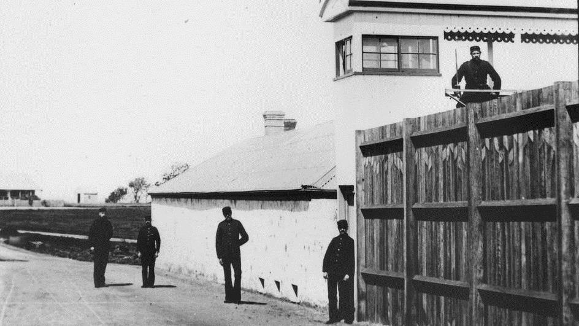

Warders pose outside the St Helena Island prison, at the mouth of the Brisbane River, in 1893. Picture: State Library of Queensland

More than two decades after the Moreton Bay penal settlement closed to convicts, a pretty little island in the bay became the new hell on earth for law-breakers.

St Helena opened in 1867 as Queensland’s first penal establishment for long-term male prisoners.

A quarantine station had been built there a year earlier, but it was soon realised it would be put to better use housing prisoners from the crowded cells at Petrie Terrace who were spilling into the hulk Proserpine moored at the Brisbane River mouth.

Over the next 65 years, St Helena confined 7500 hardy souls and was the scene of some brutal business.

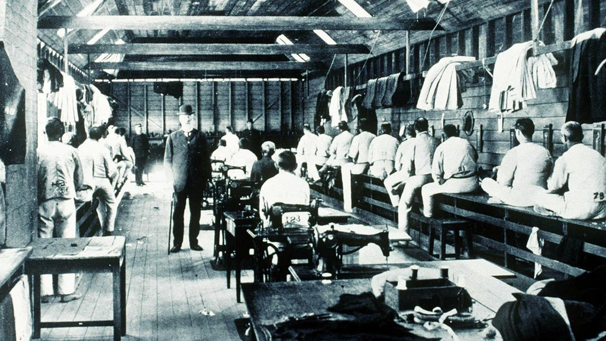

St Helena Island’s prison tailor shop with disgraced prisoners forced to avert their faces. Picture: Courtesy of the John Oxley Library

And, as one correspondent put it, attention paid to the physical or moral diseases of prisoners was slight: “The ruffian hoary-headed with crime and villainy of every description is allowed to herd with the lad sent here for a, perhaps, venial offence.”

The very worst and nameless of vices were rampant among them so that many a young man came out with his criminal education complete.

Prisoners had no name, only the number allocated on arrival. For many years, they were forbidden to speak. A hasty word or even an ugly look could earn a flogging.

The maximum was 50 lashes, but this had to be done in two sessions as 25 was enough to see skin become bone and end at the infirmary.

But even this was preferable to solitary confinement, sealed below ground in a metre-wide cell with a dirt floor that turned to mud when it rained, to sleep on. It was pitch black and silent.

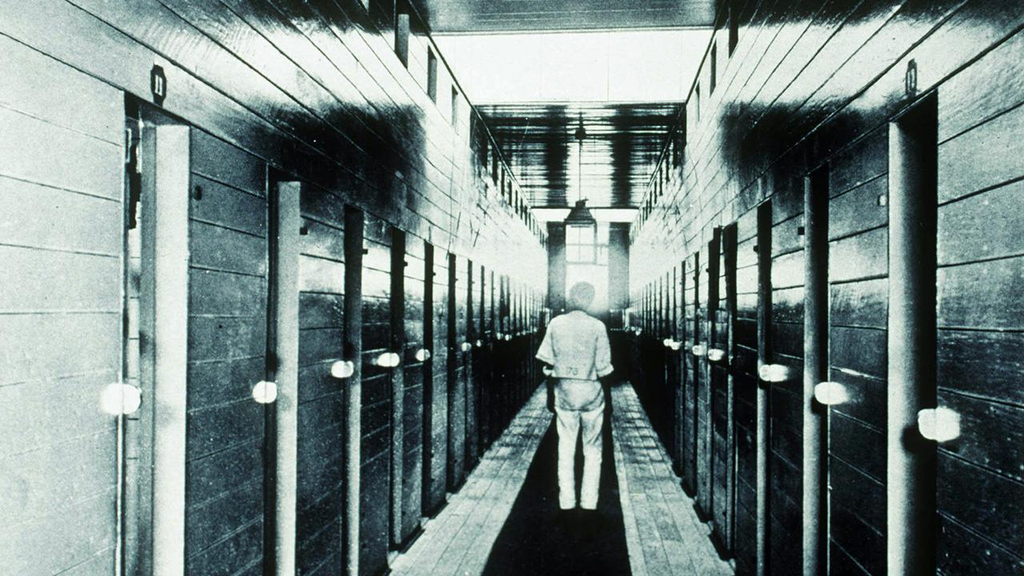

An 1878 correspondent said it might be imagined that solitary confinement would be favourable to sleep and thought, but the reverse was the case.

“From what I can learn, their time in solitude is spent in contemplating a series of horrible mental phantasmagoria”; and 28 days was enough for at least one prisoner to lose his mind.